# Chapter 3

Wenduo Wang

July 20, 2016

Problem 15

1. Let’s create a simple linear regression model for each variable against `crim`, and plot the fitted line and actual data points.

```r
library(MASS)
library(dplyr)
summary(Boston)
```

```
##       crim                zn             indus            chas
##  Min.   : 0.00632   Min.   :  0.00   Min.   : 0.46   Min.   :0.00000
##  1st Qu.: 0.08204   1st Qu.:  0.00   1st Qu.: 5.19   1st Qu.:0.00000
##  Median : 0.25651   Median :  0.00   Median : 9.69   Median :0.00000
##  Mean   : 3.61352   Mean   : 11.36   Mean   :11.14   Mean   :0.06917
##  3rd Qu.: 3.67708   3rd Qu.: 12.50   3rd Qu.:18.10   3rd Qu.:0.00000
##  Max.   :88.97620   Max.   :100.00   Max.   :27.74   Max.   :1.00000
##       nox               rm             age              dis
##  Min.   :0.3850   Min.   :3.561   Min.   :  2.90   Min.   : 1.130
##  1st Qu.:0.4490   1st Qu.:5.886   1st Qu.: 45.02   1st Qu.: 2.100
##  Median :0.5380   Median :6.208   Median : 77.50   Median : 3.207
##  Mean   :0.5547   Mean   :6.285   Mean   : 68.57   Mean   : 3.795
##  3rd Qu.:0.6240   3rd Qu.:6.623   3rd Qu.: 94.08   3rd Qu.: 5.188
##  Max.   :0.8710   Max.   :8.780   Max.   :100.00   Max.   :12.127
##       rad              tax           ptratio          black
##  Min.   : 1.000   Min.   :187.0   Min.   :12.60   Min.   :  0.32
##  1st Qu.: 4.000   1st Qu.:279.0   1st Qu.:17.40   1st Qu.:375.38
##  Median : 5.000   Median :330.0   Median :19.05   Median :391.44
##  Mean   : 9.549   Mean   :408.2   Mean   :18.46   Mean   :356.67
##  3rd Qu.:24.000   3rd Qu.:666.0   3rd Qu.:20.20   3rd Qu.:396.23
##  Max.   :24.000   Max.   :711.0   Max.   :22.00   Max.   :396.90
##      lstat            medv
##  Min.   : 1.73   Min.   : 5.00
##  1st Qu.: 6.95   1st Qu.:17.02
##  Median :11.36   Median :21.20
##  Mean   :12.65   Mean   :22.53
##  3rd Qu.:16.95   3rd Qu.:25.00
##  Max.   :37.97   Max.   :50.00
```

```r
row_no <- nrow(Boston)
training_rows <- sample(1:row_no, round(row_no*0.8))
training_set <- Boston[training_rows,]
test_set <- setdiff(Boston, training_set)
confint_df <- data.frame()
par(mfrow=c(4, 4), mar=c(2, 1, 2, 1))
for (i in c(1:ncol(Boston))){
    if (colnames(Boston)[i]=="crim"){
        next
    }
    formula <- as.formula(paste("crim~", colnames(Boston)[i]))
    lm_model <- lm(formula, data=training_set)
    plot(y=Boston$crim, x=Boston[,i], main=paste("crim ~", colnames(Boston)[i]), pch=1, col="lightgray")
    abline(lm_model$coef[1], lm_model$coef[2], col="red")
    confint_df <- rbind(confint_df, confint(lm_model)[2,])
}
print(dim(confint_df))
```

```
## [1] 13  2
```

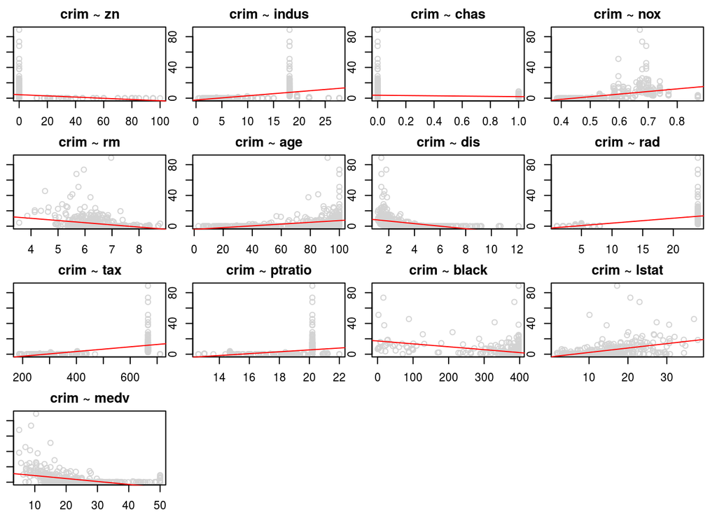

```r
colnames(confint_df) <- c("2.5%", "97.5%")
row.names(confint_df) <- colnames(Boston)[colnames(Boston)!="crim"]
```

The linear model does not fit the data very well according to the plots. To further assess the correlation, let’s have a closer look at the coefficients of these models

```r
print(confint_df)
```

```
##                2.5%       97.5%
## zn      -0.11815477 -0.03964470
## indus    0.42424385  0.66755761
## chas    -5.23879514  1.62037157
## nox     26.71097237 41.13438882
## rm      -4.13722050 -1.56195909
## age      0.08361177  0.14495109
## dis     -2.07194213 -1.26181076
## rad      0.55487296  0.71888009
## tax      0.02625293  0.03503198
## ptratio  0.81236154  1.61802960
## black   -0.04677722 -0.02872820
## lstat    0.46093031  0.68791985
## medv    -0.47335629 -0.29268225
```

The above code lists the 95% confindence intervals of coefficients for all the predictors with respect to each linear model. As seen from the result, the confident interval of the coefficient of `chas` contains zero, which means this predictor is probably not correlated with `crim`. Meanwhile, other predictors mostly have very small coefficients close to 0, with the exception of `nox`. So up to now, it appears `nox` is most likely to be a true predictor of `crim`.

(b, c) Now let’s create a linear model of `crim` on all predictors, and see their coefficients’ confident intervals.

```r
lm_model_multiple <- lm(crim~., data=training_set)
print(confint(lm_model_multiple))
```

```
##                     2.5 %       97.5 %
## (Intercept)   1.447136647 37.189667476
## zn            0.004295797  0.096914463
## indus        -0.269705963  0.147569680
## chas         -3.562555732  1.952759829
## nox         -23.147958338  2.442460687
## rm           -0.915785411  2.103150432
## age          -0.037337414  0.047274217
## dis          -1.776459345 -0.421569804
## rad           0.433226399  0.861503157
## tax          -0.019492391  0.006210997
## ptratio      -0.782835342  0.105974591
## black        -0.016312590  0.001139406
## lstat        -0.064293534  0.297059922
## medv         -0.387996661 -0.106640296
```

4. To inspect if there is a correlation in the form of
   $$crim = \beta_0 + \beta_1 X + \beta_2 X^2 + \beta_3 X^3$$
   we create a linear regression model for each predictor against `crim`, in the format of `lm(crim ~ x + x^2 + x^3, data=training_set)`, and then inspect the model’s coefficient confidence interval.

```r
for (i in c(1:ncol(Boston))){
    if (colnames(Boston)[i]=="crim"){
        next
    }
    variable <- colnames(Boston)[i]
    formula <- as.formula(paste("crim ~ ", variable, " + I(", variable, "^2) + I(", variable, "^3)", sep=""))
    cat("For predictor:", colnames(Boston)[i], "\n")
    pn_model_3 <- lm(formula, data=training_set)
    print(confint(pn_model_3))
    cat("\n")
}
```

```
## For predictor: zn
##                     2.5 %        97.5 %
## (Intercept)  3.9973884592  6.033143e+00
## zn          -0.6229915707 -8.786374e-02
## I(zn^2)     -0.0025443674  1.686508e-02
## I(zn^3)     -0.0001237034  3.783687e-05
##
## For predictor: indus
##                    2.5 %       97.5 %
## (Intercept)  0.275859418  7.956366575
## indus       -3.308129104 -0.963066433
## I(indus^2)   0.171936119  0.363341593
## I(indus^3)  -0.009678317 -0.005006432
##
## For predictor: chas
##                 2.5 %   97.5 %
## (Intercept)  2.952033 4.818861
## chas        -5.238795 1.620372
## I(chas^2)          NA       NA
## I(chas^3)          NA       NA
##
## For predictor: nox
##                  2.5 %    97.5 %
## (Intercept)   168.7969  330.6697
## nox         -1780.3149 -959.3749
## I(nox^2)     1730.9203 3082.7142
## I(nox^3)    -1695.6734 -972.1941
##
## For predictor: rm
##                    2.5 %      97.5 %
## (Intercept)  -55.6402490 258.0116702
## rm          -108.3921760  43.4993500
## I(rm^2)       -8.7936123  15.4852349
## I(rm^3)       -0.7452238   0.5332704
##
## For predictor: age
##                     2.5 %       97.5 %
## (Intercept) -9.532540e+00 3.7937582850
## age         -1.373161e-01 0.7441893529
## I(age^2)    -1.644148e-02 0.0006717479
```

[output cut: 35 more lines]

```
## I(black^3)  -1.199556e-06 8.736927e-07
##
## For predictor: lstat
##                    2.5 %       97.5 %
## (Intercept) -3.605637628 5.8793822564
## lstat       -1.477404003 0.6766887024
## I(lstat^2)  -0.017798814 0.1210009146
## I(lstat^3)  -0.002031194 0.0005583125
##
## For predictor: medv
##                    2.5 %     97.5 %
## (Intercept) 48.094422643 63.2508074
## medv        -6.336313936 -4.3674242
## I(medv^2)    0.124459459  0.2028412
## I(medv^3)   -0.002033628 -0.0011020
```

As seen from the output confidence intervals, it is first noticed that `chas^2` and `chas^3` do not have coefficients. That is due to that `chas` is a binary variable, whose squre or cube is essentially itself, so in this case `chas`, `chas^2` and `chas^3` are linearly related, and therefore the latter two polynomial terms are not fitted in the model. `chas` put aside, several polynomial terms exhibit correlation with `crim`, whose 95% coefficient confidence intervals exclude zero. For example, `nox^2` and `nox^3`.